# Module Six Activity

For the module six activity, you will design and implement a Python-based dynamic data visualization dashboard. The goal is to apply principles of data visualization design, utilize advanced Python visualization libraries, and implement multi-level exploration techniques with interactive elements. You will also customize the visualizations to enhance usability, accessibility, and aesthetic appeal.

### Multi-level Data Exploration Overview

Multi-level data exploration refers to the process of examining and analyzing data at different levels of detail or abstraction to uncover patterns, insights, and relationships. It’s like zooming in and out of your data to see both the big picture and the finer details from high-level to low-level exploration.

#### High-Level Exploration – Look at broad summaries:

- Mean, median, min, max
- istograms, box plots
- Count of categories, missing data

#### Mid-Level Exploration – Compare groups or variables:

- Correlations between variables
- Group-by aggregations (e.g., average sales per region)
- Visual comparisons like bar plots or scatter plots

#### Low-Level Exploration – Dive deep into specific cases:

- Investigating outliers
- Looking at individual records
- Tracing data transformations

It’s often used in exploration data analysis (EDA), business intelligence dashboards, or machine learning prep, helping analysts or data scientists move between summaries and specifics to better understand the data.

*Note:* there are five parts to this assignment. Parts one through four are evaluated using the html output. Part five is a reflection paper.

Once your code is complete, you will download this notebook as an HTML file by clicking **File**, then **Download As**, then **HTML (.html)** from the Jupyter menu bar. Validate that your code, output, and all visualizations (rendered as images using the display() function) are visible in the html file before submission.

*Missing Blocks:* Ensure that you have clicked **Run** for all blocks before downloading as an HTML file or the block may be missing from your submission. **Images** must be called using the *display()* function, for example: **display(Image(filename="output/{image_name}.png"))** or you can use the same **show()** function as noted for the interactive charts.

Specifically, you must address the items from the rubric criteria.

### Part One: Data Set Selection and Preparation

#### Preprocess the data set using Python. Consider the following:

- Are there missing values in the dataset?
- Are there numerical values that need to be normalized or scaled to ensure accurate comparison and visualization?

### Part Two: Static Visualization with Design Principles

#### Create multiple static visualizations using Matplotlib or Seaborn to highlight key insights from the data set. Consider the following:

- Heatmap showing correlations between variables
- Hierarchical bar chart comparing categories and subcategories
- Time series line chart with annotations

#### Apply visualization design principles. Include the following:

- Use effective color palettes
- Label axes, titles, and legends clearly
- Adjust scale and proportions for clarity

### Part Three: Interactive Visualizations

#### Create multiple interactive visualizations using Plotly. Include the following:

- A visualization that uses a drill-down or zoom feature
- Another visualization using Overview+Detail

#### Add interactive elements to your visualizations. Consider the following:

- Tooltips that reveal additional information on hover
- Dropdown menus or buttons to filter or control the data display

### Part Four: Customization and Animation

#### Customize your visualizations. Include the following:

- A consistent visual theme (fonts, colors, gridlines)
- An optimized layout for usability and clarity

#### Add animation and transition effects to your interactive visualizations.

### Part Five: Reflection

#### Explain how specific design choices contributed to the clarity and impact of the visualizations.

#### Describe any challenges you faced when implementing interactivity and animation. Include the following:

- How you addressed each challenge

#### Evaluate how accessibility and cognitive load considerations were incorporated into the design of the visualizations.

*Note:* The interactive and animated visualizations from parts three and four will not render successfully in the html output without using the recommended **{variable}.show()** function for the interactive charts and **HTML({variable}.to_jshtml())** for the animated chart.

*To Begin:* This Python template program has been broken down into segments as a guide for what steps you should do at a minimum to complete this activity. Look for the **# To Do:** comments. These are placeholders for you to provide Python code segments. Fill out all **# To Do:** code segments to complete this program.  
*Once Complete:* Execute a "Kernel restart and run all" to verify that all your code works as a single unit by clicking **Kernel**, then **Restart & Run All** before downloading as html.

*Hint:* If you need to install additional packages, see one of the earlier modules on how to configure and call a requirements.txt file.

## Import the Required Packages

```python
## Import the Required Packages
import pandas as pd
import numpy as np
import matplotlib.pyplot as plt     # for creating charts & saving visuals
from matplotlib.animation import FuncAnimation
import seaborn as sns    # for advanced & visually appealing charts
from sklearn.preprocessing import MinMaxScaler    # a preprocessing tool from sklearn to normalize data values
import plotly.express as px
import plotly.graph_objects as go
from plotly.subplots import make_subplots

import os  # used to create folders safely before saving output files

from IPython.display import Image, display # for image rendering in html output
from IPython.display import HTML  # required for rendering animations in exported HTML
```

# Part One: Dataset Selection and Preparation

You are given a real-world dataset with hierarchical and multi-dimensional data. The dataset consists of global COVID-19 total death cases (e.g., country, region, time-series data). Obtained from https://github.com/owid/covid-19-data/blob/master/public/data/cases_deaths/total_deaths.csv. The dataset is located in the data folder in the Codio filetree: `data/COVID_total_deaths.csv`.

#### Preprocess the dataset to:

- Check for missing values.
- Normalize or scale numerical data where appropriate.

## Define the file path for the dataset

```python
## Define the file path for the dataset
file_path = "data/COVID_total_deaths.csv"
```

## Load the dataset

```python
## Load the dataset
# To Do: write a try/catch block to load the given dataset

try:
    # Read the CSV into a dataframe
    # low_memory=False helps avoid dtype warnings on wide CSVs
    covid_raw_df = pd.read_csv(file_path, low_memory=False)

    # Make a working copy for cleaning steps so the raw version stays unchanged
    covid_df = covid_raw_df.copy()

    print("Dataset loaded successfully.")
    print("Dataset shape:", covid_df.shape)

except FileNotFoundError:
    print(f"Error: File not found at path: {file_path}")

except Exception as e:
    print(f"An unexpected error occurred while loading the dataset: {e}")
```

```
Dataset loaded successfully.
Dataset shape: (1674, 247)
```

## Display the first few rows of the dataset for an initial overview

```python
## Display the first few rows of the dataset for an initial overview
print("Preview of the dataset:")

# To Do: Display a few rows of the dataset for inspection
# display() is reliable for HTML export
display(covid_df.head())
```

```
Preview of the dataset:
```

|  | date | World | Afghanistan | Africa | Albania | Algeria | American Samoa | Andorra | Angola | Anguilla | ... | Uruguay | Uzbekistan | Vanuatu | Vatican | Venezuela | Vietnam | Wallis and Futuna | Yemen | Zambia | Zimbabwe |
| --- | --- | --- | --- | --- | --- | --- | --- | --- | --- | --- | --- | --- | --- | --- | --- | --- | --- | --- | --- | --- | --- |
| 0 | 2020-01-05 | 3 | 0 | 0 | 0 | 0 | 0 | 0 | 0 | 0 | ... | 0 | 0 | 0 | 0 | 0 | 0 | 0 | 0 | 0 | 0 |
| 1 | 2020-01-06 | 3 | 0 | 0 | 0 | 0 | 0 | 0 | 0 | 0 | ... | 0 | 0 | 0 | 0 | 0 | 0 | 0 | 0 | 0 | 0 |
| 2 | 2020-01-07 | 3 | 0 | 0 | 0 | 0 | 0 | 0 | 0 | 0 | ... | 0 | 0 | 0 | 0 | 0 | 0 | 0 | 0 | 0 | 0 |
| 3 | 2020-01-08 | 3 | 0 | 0 | 0 | 0 | 0 | 0 | 0 | 0 | ... | 0 | 0 | 0 | 0 | 0 | 0 | 0 | 0 | 0 | 0 |
| 4 | 2020-01-09 | 3 | 0 | 0 | 0 | 0 | 0 | 0 | 0 | 0 | ... | 0 | 0 | 0 | 0 | 0 | 0 | 0 | 0 | 0 | 0 |

5 rows × 247 columns

## Explore the structure of the dataset

```python
## Explore the structure of the dataset
print("Dataset information:")

# To Do: Display dataset information for inspection
# info() shows column names, dtypes, null counts
covid_df.info()
```

```
Dataset information:
<class 'pandas.core.frame.DataFrame'>
RangeIndex: 1674 entries, 0 to 1673
Columns: 247 entries, date to Zimbabwe
dtypes: int64(246), object(1)
memory usage: 3.2+ MB
```

## Check for missing values

```python
## Check for missing values
print("Checking for missing values...")

# To Do: check for missing values per column, print the missing values per column
missing_values = covid_df.isnull().sum()

# Print missing count for every column (wide dataset, but explicit)
print(missing_values)

# Print only columns that actually contain missing values
print("\nColumns with missing values (if any):")
print(missing_values[missing_values > 0])

# Print total missing cells
print("\nTotal missing values in dataset:", int(missing_values.sum()))
```

```
Checking for missing values...
date                 0
World                0
Afghanistan          0
Africa               0
Albania              0
                    ..
Vietnam              0
Wallis and Futuna    0
Yemen                0
Zambia               0
Zimbabwe             0
Length: 247, dtype: int64

Columns with missing values (if any):
Series([], dtype: int64)

Total missing values in dataset: 0
```

## Handle missing values

```python
## Handle missing values
# If there are missing values, decide how to handle them
print("Handling missing values...")

# To Do: Drop rows with missing data as a simple approch. Display number of rows after dropping missing values.

# Capture the row count before cleaning for summary reporting later
original_rows = covid_df.shape[0]

# Drop any row that contains NaN in any column
covid_df = covid_df.dropna()

# Capture final row count after cleaning
final_rows = covid_df.shape[0]

print(f"Rows before dropping missing values: {original_rows}")
print(f"Rows after dropping missing values:  {final_rows}")
print(f"Rows removed: {original_rows - final_rows}")
```

```
Handling missing values...
Rows before dropping missing values: 1674
Rows after dropping missing values:  1674
Rows removed: 0
```

## Normalize or scale numerical data where appropriate

```python
## Normalize or scale numerical data where appropriate
print("Normalizing numerical data...")

# To Do: Select numerical columns for normalization. Display numerical columns identified for normalization.
# The dataset is wide: date + many locations. We scale only numeric columns.
numerical_cols = covid_df.select_dtypes(include=["int64", "float64"]).columns

print("Numerical columns identified for normalization:")
print(numerical_cols.tolist())
print(f"Total numerical columns: {len(numerical_cols)}")
```

```
Normalizing numerical data...
Numerical columns identified for normalization:
['World', 'Afghanistan', 'Africa', 'Albania', 'Algeria', 'American Samoa', 'Andorra', 'Angola', 'Anguilla', 'Antigua and Barbuda', 'Argentina', 'Armenia', 'Aruba', 'Asia', 'Australia', 'Austria', 'Azerbaijan', 'Bahamas', 'Bahrain', 'Bangladesh', 'Barbados', 'Belarus', 'Belgium', 'Belize', 'Benin', '…
Total numerical columns: 246
```

```python
# To Do: Apply min-max normalization to scale numerical data between 0 and 1
scaler = MinMaxScaler()

# Scale only numeric columns (date stays unchanged)
covid_df.loc[:, numerical_cols] = scaler.fit_transform(covid_df[numerical_cols])

# Optional quick sanity check: mins should be ~0 and maxes ~1
print("\nNormalization complete (sample min/max check on first 5 numeric columns):")
display(covid_df[numerical_cols[:5]].agg(["min", "max"]))
```

```
Normalization complete (sample min/max check on first 5 numeric columns):
```

|  | World | Afghanistan | Africa | Albania | Algeria |
| --- | --- | --- | --- | --- | --- |
| min | 0.0 | 0.0 | 0.0 | 0.0 | 0.0 |
| max | 1.0 | 1.0 | 1.0 | 1.0 | 1.0 |

```python
# To Do: Round normalized values to 4 decimal places to reduce file size
covid_df.loc[:, numerical_cols] = covid_df[numerical_cols].round(4)

print("Normalization and rounding complete.")
```

```
Normalization and rounding complete.
```

## Save the preprocessed dataset

```python
## Save the preprocessed dataset
# To Do: Save the cleaned preprocessed data to a file. Name the file: "COVID_total_deaths_preprocessed.csv" and save it in the 'data' folder.
#        Then, display "\nPreprocessed dataset saved to <output file path/file name>".

output_file = "data/COVID_total_deaths_preprocessed.csv"

# Save without index so you don’t create an extra column
covid_df.to_csv(output_file, index=False)

print(f"\nPreprocessed dataset saved to {output_file}")
```

```
Preprocessed dataset saved to data/COVID_total_deaths_preprocessed.csv
```

## Summary of the preprocessing steps

```python
## Summary of the preprocessing steps
print("Summary of preprocessing steps:")

# To Do: Display the Original dataset rows
print(f"Original dataset rows: {covid_raw_df.shape[0]}")
```

```
Summary of preprocessing steps:
Original dataset rows: 1674
```

```python
# To Do: Display the total missing values handled
rows_removed = original_rows - final_rows
print(f"Rows removed due to missing values: {rows_removed}")
```

```
Rows removed due to missing values: 0
```

```python
# To Do: Display the final dataset rows after cleaning
print(f"Final dataset rows after cleaning: {final_rows}")
```

```
Final dataset rows after cleaning: 1674
```

```python
# To Do: Display the numerical data normalized and rounded
# Ensure numerical_cols is a plain Python list so printing works consistently
numerical_cols = list(numerical_cols)

print("Numerical columns normalized and rounded (4 decimal places):")
print(numerical_cols)

print("\nSample of normalized data (first 5 rows, first 5 numeric columns):")
display(covid_df[numerical_cols[:5]].head())
```

```
Numerical columns normalized and rounded (4 decimal places):
['World', 'Afghanistan', 'Africa', 'Albania', 'Algeria', 'American Samoa', 'Andorra', 'Angola', 'Anguilla', 'Antigua and Barbuda', 'Argentina', 'Armenia', 'Aruba', 'Asia', 'Australia', 'Austria', 'Azerbaijan', 'Bahamas', 'Bahrain', 'Bangladesh', 'Barbados', 'Belarus', 'Belgium', 'Belize', 'Benin', '…

Sample of normalized data (first 5 rows, first 5 numeric columns):
```

|  | World | Afghanistan | Africa | Albania | Algeria |
| --- | --- | --- | --- | --- | --- |
| 0 | 0.0 | 0.0 | 0.0 | 0.0 | 0.0 |
| 1 | 0.0 | 0.0 | 0.0 | 0.0 | 0.0 |
| 2 | 0.0 | 0.0 | 0.0 | 0.0 | 0.0 |
| 3 | 0.0 | 0.0 | 0.0 | 0.0 | 0.0 |
| 4 | 0.0 | 0.0 | 0.0 | 0.0 | 0.0 |

## Display a preview of the cleaned dataset

```python
## Display a preview of the cleaned dataset
print("Preview of the cleaned dataset:")

# To Do: Display a few rows of the cleaned data as a preview
display(covid_df.head())
print("Cleaned dataset shape:", covid_df.shape)
```

```
Preview of the cleaned dataset:
```

|  | date | World | Afghanistan | Africa | Albania | Algeria | American Samoa | Andorra | Angola | Anguilla | ... | Uruguay | Uzbekistan | Vanuatu | Vatican | Venezuela | Vietnam | Wallis and Futuna | Yemen | Zambia | Zimbabwe |
| --- | --- | --- | --- | --- | --- | --- | --- | --- | --- | --- | --- | --- | --- | --- | --- | --- | --- | --- | --- | --- | --- |
| 0 | 2020-01-05 | 0.0 | 0.0 | 0.0 | 0.0 | 0.0 | 0.0 | 0.0 | 0.0 | 0.0 | ... | 0.0 | 0.0 | 0.0 | 0 | 0.0 | 0.0 | 0.0 | 0.0 | 0.0 | 0.0 |
| 1 | 2020-01-06 | 0.0 | 0.0 | 0.0 | 0.0 | 0.0 | 0.0 | 0.0 | 0.0 | 0.0 | ... | 0.0 | 0.0 | 0.0 | 0 | 0.0 | 0.0 | 0.0 | 0.0 | 0.0 | 0.0 |
| 2 | 2020-01-07 | 0.0 | 0.0 | 0.0 | 0.0 | 0.0 | 0.0 | 0.0 | 0.0 | 0.0 | ... | 0.0 | 0.0 | 0.0 | 0 | 0.0 | 0.0 | 0.0 | 0.0 | 0.0 | 0.0 |
| 3 | 2020-01-08 | 0.0 | 0.0 | 0.0 | 0.0 | 0.0 | 0.0 | 0.0 | 0.0 | 0.0 | ... | 0.0 | 0.0 | 0.0 | 0 | 0.0 | 0.0 | 0.0 | 0.0 | 0.0 | 0.0 |
| 4 | 2020-01-09 | 0.0 | 0.0 | 0.0 | 0.0 | 0.0 | 0.0 | 0.0 | 0.0 | 0.0 | ... | 0.0 | 0.0 | 0.0 | 0 | 0.0 | 0.0 | 0.0 | 0.0 | 0.0 | 0.0 |

5 rows × 247 columns

```
Cleaned dataset shape: (1674, 247)
```

# Part Two: Static Visualizations with Design Principles

#### Create multiple static visualizations using Matplotlib or Seaborn that highlight key insights from the dataset.

Consider the following examples:

- A heatmap showing correlations between variables.
- A hierarchical bar chart comparing categories and subcategories.
- A time series line chart with annotations showing trends.

*Note:* Save all these files as PNG files in the output folder to be render in html using the display() function or the show() function for the chart.

#### Apply visualization design principles.

Include the following:

- Use effective color palettes (color theory).
- Label axes, titles, and legends following typography best practices.
- Ensure proportions and scaling are appropriate for the data.
- Consider accessibility (e.g., colorblind-friendly palettes).

## Load the preprocessed dataset from Part One above

```python
## Load the preprocessed dataset from Part One above
# To Do: Load the cleaned/preprocessed dataset you created in Part 1 of this assignment. This dataset should be in the 'data' folder.

try:
    covid_clean_df = pd.read_csv("data/COVID_total_deaths_preprocessed.csv", low_memory=False)
    print("Preprocessed dataset loaded successfully.")

    # Convert date for time-based plotting
    covid_clean_df["date"] = pd.to_datetime(covid_clean_df["date"], errors="coerce")

    # Drop bad dates and sort
    covid_clean_df = covid_clean_df.dropna(subset=["date"]).copy()
    covid_clean_df = covid_clean_df.sort_values("date").reset_index(drop=True)

    print("Dataset shape:", covid_clean_df.shape)
    display(covid_clean_df.head())

except FileNotFoundError:
    print("Error: Preprocessed dataset not found. Make sure Part One saved: data/COVID_total_deaths_preprocessed.csv")
except Exception as e:
    print(f"An unexpected error occurred while loading the preprocessed dataset: {e}")
```

```
Preprocessed dataset loaded successfully.
Dataset shape: (1674, 247)
```

|  | date | World | Afghanistan | Africa | Albania | Algeria | American Samoa | Andorra | Angola | Anguilla | ... | Uruguay | Uzbekistan | Vanuatu | Vatican | Venezuela | Vietnam | Wallis and Futuna | Yemen | Zambia | Zimbabwe |
| --- | --- | --- | --- | --- | --- | --- | --- | --- | --- | --- | --- | --- | --- | --- | --- | --- | --- | --- | --- | --- | --- |
| 0 | 2020-01-05 | 0.0 | 0.0 | 0.0 | 0.0 | 0.0 | 0.0 | 0.0 | 0.0 | 0.0 | ... | 0.0 | 0.0 | 0.0 | 0 | 0.0 | 0.0 | 0.0 | 0.0 | 0.0 | 0.0 |
| 1 | 2020-01-06 | 0.0 | 0.0 | 0.0 | 0.0 | 0.0 | 0.0 | 0.0 | 0.0 | 0.0 | ... | 0.0 | 0.0 | 0.0 | 0 | 0.0 | 0.0 | 0.0 | 0.0 | 0.0 | 0.0 |
| 2 | 2020-01-07 | 0.0 | 0.0 | 0.0 | 0.0 | 0.0 | 0.0 | 0.0 | 0.0 | 0.0 | ... | 0.0 | 0.0 | 0.0 | 0 | 0.0 | 0.0 | 0.0 | 0.0 | 0.0 | 0.0 |
| 3 | 2020-01-08 | 0.0 | 0.0 | 0.0 | 0.0 | 0.0 | 0.0 | 0.0 | 0.0 | 0.0 | ... | 0.0 | 0.0 | 0.0 | 0 | 0.0 | 0.0 | 0.0 | 0.0 | 0.0 | 0.0 |
| 4 | 2020-01-09 | 0.0 | 0.0 | 0.0 | 0.0 | 0.0 | 0.0 | 0.0 | 0.0 | 0.0 | ... | 0.0 | 0.0 | 0.0 | 0 | 0.0 | 0.0 | 0.0 | 0.0 | 0.0 | 0.0 |

5 rows × 247 columns

## Display the first few rows and column names for confirmation

```python
## Display the first few rows and column names for confirmation
print("Column names:")

# To Do: Display the first few column names.
print("First 20 column names:")
print(covid_clean_df.columns[:20].tolist())
print(f"\nTotal columns: {len(covid_clean_df.columns)}")

print("\n'date' column present?", "date" in covid_clean_df.columns)
```

```
Column names:
First 20 column names:
['date', 'World', 'Afghanistan', 'Africa', 'Albania', 'Algeria', 'American Samoa', 'Andorra', 'Angola', 'Anguilla', 'Antigua and Barbuda', 'Argentina', 'Armenia', 'Aruba', 'Asia', 'Australia', 'Austria', 'Azerbaijan', 'Bahamas', 'Bahrain']

Total columns: 247

'date' column present? True
```

```python
print("Preview of the dataset:")

# To Do: Display the first few rows.
display(covid_clean_df.head())
print("Dataset shape:", covid_clean_df.shape)
```

```
Preview of the dataset:
```

|  | date | World | Afghanistan | Africa | Albania | Algeria | American Samoa | Andorra | Angola | Anguilla | ... | Uruguay | Uzbekistan | Vanuatu | Vatican | Venezuela | Vietnam | Wallis and Futuna | Yemen | Zambia | Zimbabwe |
| --- | --- | --- | --- | --- | --- | --- | --- | --- | --- | --- | --- | --- | --- | --- | --- | --- | --- | --- | --- | --- | --- |
| 0 | 2020-01-05 | 0.0 | 0.0 | 0.0 | 0.0 | 0.0 | 0.0 | 0.0 | 0.0 | 0.0 | ... | 0.0 | 0.0 | 0.0 | 0 | 0.0 | 0.0 | 0.0 | 0.0 | 0.0 | 0.0 |
| 1 | 2020-01-06 | 0.0 | 0.0 | 0.0 | 0.0 | 0.0 | 0.0 | 0.0 | 0.0 | 0.0 | ... | 0.0 | 0.0 | 0.0 | 0 | 0.0 | 0.0 | 0.0 | 0.0 | 0.0 | 0.0 |
| 2 | 2020-01-07 | 0.0 | 0.0 | 0.0 | 0.0 | 0.0 | 0.0 | 0.0 | 0.0 | 0.0 | ... | 0.0 | 0.0 | 0.0 | 0 | 0.0 | 0.0 | 0.0 | 0.0 | 0.0 | 0.0 |
| 3 | 2020-01-08 | 0.0 | 0.0 | 0.0 | 0.0 | 0.0 | 0.0 | 0.0 | 0.0 | 0.0 | ... | 0.0 | 0.0 | 0.0 | 0 | 0.0 | 0.0 | 0.0 | 0.0 | 0.0 | 0.0 |
| 4 | 2020-01-09 | 0.0 | 0.0 | 0.0 | 0.0 | 0.0 | 0.0 | 0.0 | 0.0 | 0.0 | ... | 0.0 | 0.0 | 0.0 | 0 | 0.0 | 0.0 | 0.0 | 0.0 | 0.0 | 0.0 |

5 rows × 247 columns

```
Dataset shape: (1674, 247)
```

## Create Visualizations

### Visualization 1: Correlation Heatmap Between Countries (Top 10 by Total Deaths)

```python
### Visualization 1: Correlation Heatmap Between Countries (Top 10 by Total Deaths)
def create_correlation_heatmap(data):
    print("Aggregating total deaths by country...")
    # To Do: Aggregate total deaths by country

    os.makedirs("output", exist_ok=True)

    # Work on a copy and ensure the date column is clean
    df = data.copy()
    df["date"] = pd.to_datetime(df["date"], errors="coerce")
    df = df.dropna(subset=["date"]).sort_values("date")

    print("Selecting top 10 countries by total deaths...")
    # To Do: Select the top 10 countries by total deaths

    # Use the raw dataset to rank top countries so “top 10” is meaningful (not distorted by normalization)
    raw_df = pd.read_csv("data/COVID_total_deaths.csv", low_memory=False)
    raw_df["date"] = pd.to_datetime(raw_df["date"], errors="coerce")
    raw_df = raw_df.dropna(subset=["date"]).sort_values("date")

    totals = raw_df.drop(columns=["date"]).iloc[-1].sort_values(ascending=False)

    exclude = {
        "World", "Africa", "Europe", "North America", "South America", "Asia", "Oceania",
        "European Union (27)",
        "High-income countries", "Upper-middle-income countries",
        "Lower-middle-income countries", "Low-income countries"
    }
    totals = totals.drop(labels=[c for c in exclude if c in totals.index], errors="ignore")

    top_10_countries = totals.head(10).index.tolist()
    print("Top 10 countries selected:", top_10_countries)

    print("Filtering the dataset for the top countries...")
    # To Do: Filter the dataset for the top 10 countries
    filtered_data = df[["date"] + top_10_countries].copy()

    print("Preparing country data for correlation...")
    # To Do: Aggregate total deaths for each country
    # Correlation needs aligned time series, so use date as index
    pivot_data = filtered_data.set_index("date")

    print("Computing the correlation matrix...")
    # To Do: Compute the correlation matrix across countries
    corr_matrix = pivot_data.corr()

    # Debugging: Print the correlation matrix shape and preview
    # To Do: Display the correlation matrix shape.
    print("Correlation matrix shape:", corr_matrix.shape)
    display(corr_matrix.head())

    print("Plotting the heatmap...")
    # To Do: Plot the heatmap
    plt.figure(figsize=(12, 8))
    sns.heatmap(corr_matrix, cmap="viridis", linewidths=0.5)

    # To Do: Add title and axis labels
    plt.title("Correlation of COVID-19 Total Deaths Trends (Top 10 Countries)")
    plt.xlabel("Country")
    plt.ylabel("Country")

    # To Do: Save the plot to a png file in the 'output' folder
    output_file = "output/correlation_heatmap.png"
    plt.savefig(output_file, bbox_inches="tight")
    plt.close()

    # To Do: Use the display() function to render the generated png image in the html output
    display(Image(filename=output_file))
```

### Visualization 2: Hierarchical Bar Chart (Top 20 Countries by Total Deaths)

```python
### Visualization 2: Hierarchical Bar Chart (Top 20 Countries by Total Deaths)
def create_bar_chart(data):
    print("Creating bar chart for top 20 countries...")
    # To Do: Aggregate total deaths by country

    os.makedirs("output", exist_ok=True)

    # Use raw totals for a more interpretable bar chart
    raw_df = pd.read_csv("data/COVID_total_deaths.csv", low_memory=False)
    raw_df["date"] = pd.to_datetime(raw_df["date"], errors="coerce")
    raw_df = raw_df.dropna(subset=["date"]).sort_values("date")

    country_totals = raw_df.drop(columns=["date"]).iloc[-1].sort_values(ascending=False)

    exclude = {
        "World", "Africa", "Europe", "North America", "South America", "Asia", "Oceania",
        "European Union (27)",
        "High-income countries", "Upper-middle-income countries",
        "Lower-middle-income countries", "Low-income countries"
    }
    country_totals = country_totals.drop(labels=[c for c in exclude if c in country_totals.index], errors="ignore")

    # To Do: Sort by total deaths and select the top 20 countries
    top_20 = country_totals.head(20)

    # To Do: Create the bar chart
    plt.figure(figsize=(14, 7))
    top_20.sort_values(ascending=True).plot(kind="barh")

    # To Do: Add labels and title
    plt.title("Top 20 Countries by Total COVID-19 Deaths (Cumulative)")
    plt.xlabel("Total Deaths")
    plt.ylabel("Country")
    plt.grid(axis="x", linestyle="--", alpha=0.4)

    # To Do: Save the plot to a png file in the 'output'folder
    output_file = "output/top_20_countries_bar_chart.png"
    plt.savefig(output_file, bbox_inches="tight")
    plt.close()

    # To Do: Use the display() function to render the generated png image in the html output
    display(Image(filename=output_file))
```

### Visualization 3: Time Series Chart (Global Trends in Total Deaths)

```python
### Visualization 3: Time Series Chart (Global Trends in Total Deaths)
def create_time_series_chart(data):
    print("Creating global time series chart...")
    # To Do: Aggregate total deaths across all countries for each date

    os.makedirs("output", exist_ok=True)

    # Use raw dataset for clearer interpretation and to avoid “flat 1.0” issues from rounded normalization
    raw_df = pd.read_csv("data/COVID_total_deaths.csv", low_memory=False)
    raw_df["date"] = pd.to_datetime(raw_df["date"], errors="coerce")
    raw_df = raw_df.dropna(subset=["date"]).sort_values("date")

    # Use "World" if available (avoids double-counting)
    if "World" in raw_df.columns:
        global_trend = raw_df["World"]
        y_label = "Total Deaths"
    else:
        global_trend = raw_df.drop(columns=["date"]).sum(axis=1, numeric_only=True)
        y_label = "Total Deaths (Summed Columns)"

    # To Do: Create the time series chart
    plt.figure(figsize=(14, 7))
    plt.plot(raw_df["date"], global_trend)

    # To Do: Add labels and title
    plt.title("Global COVID-19 Total Deaths Over Time")
    plt.xlabel("Date")
    plt.ylabel(y_label)
    plt.grid(True, linestyle="--", alpha=0.4)

    # Add simple annotations (first non-zero point + largest jump)
    nonzero = global_trend[global_trend > 0]
    if not nonzero.empty:
        first_idx = nonzero.index[0]
        first_date = raw_df.loc[first_idx, "date"]
        first_val = global_trend.loc[first_idx]
        plt.scatter(first_date, first_val)
        plt.annotate(
            "First non-zero",
            xy=(first_date, first_val),
            textcoords="offset points",
            xytext=(10, 10),
            arrowprops=dict(arrowstyle="->")
        )

    daily_change = global_trend.diff().fillna(0)
    peak_idx = daily_change.idxmax()
    peak_date = raw_df.loc[peak_idx, "date"]
    peak_val = global_trend.loc[peak_idx]
    plt.scatter(peak_date, peak_val)
    plt.annotate(
        "Largest jump",
        xy=(peak_date, peak_val),
        textcoords="offset points",
        xytext=(10, -20),
        arrowprops=dict(arrowstyle="->")
    )

    # To Do: Save the plot into a png file under the 'output' folder
    output_file = "output/global_time_series.png"
    plt.savefig(output_file, bbox_inches="tight")
    plt.close()

    # To Do: Use the display() function to render the generated png image in the html output
    display(Image(filename=output_file))
```

## Call the visualization functions

```
Generating visualizations...

Visualization 1. Calling to create correlation heatmap...
Aggregating total deaths by country...
Selecting top 10 countries by total deaths...
Top 10 countries selected: ['United States', 'Brazil', 'India', 'Russia', 'Mexico', 'United Kingdom', 'Peru', 'Italy', 'Germany', 'France']
Filtering the dataset for the top countries...
Preparing country data for correlation...
Computing the correlation matrix...
Correlation matrix shape: (10, 10)
```

|  | United States | Brazil | India | Russia | Mexico | United Kingdom | Peru | Italy | Germany | France |
| --- | --- | --- | --- | --- | --- | --- | --- | --- | --- | --- |
| United States | 1.000000 | 0.973092 | 0.966117 | 0.982737 | 0.968561 | 0.986802 | 0.949986 | 0.993392 | 0.994906 | 0.989131 |
| Brazil | 0.973092 | 1.000000 | 0.995882 | 0.958543 | 0.986247 | 0.971535 | 0.986426 | 0.977381 | 0.964716 | 0.981952 |
| India | 0.966117 | 0.995882 | 1.000000 | 0.962781 | 0.975444 | 0.955708 | 0.974726 | 0.965502 | 0.955578 | 0.970386 |
| Russia | 0.982737 | 0.958543 | 0.962781 | 1.000000 | 0.936183 | 0.946007 | 0.911421 | 0.962384 | 0.975298 | 0.957745 |
| Mexico | 0.968561 | 0.986247 | 0.975444 | 0.936183 | 1.000000 | 0.981490 | 0.991765 | 0.975277 | 0.958367 | 0.984034 |

```
Plotting the heatmap...
```

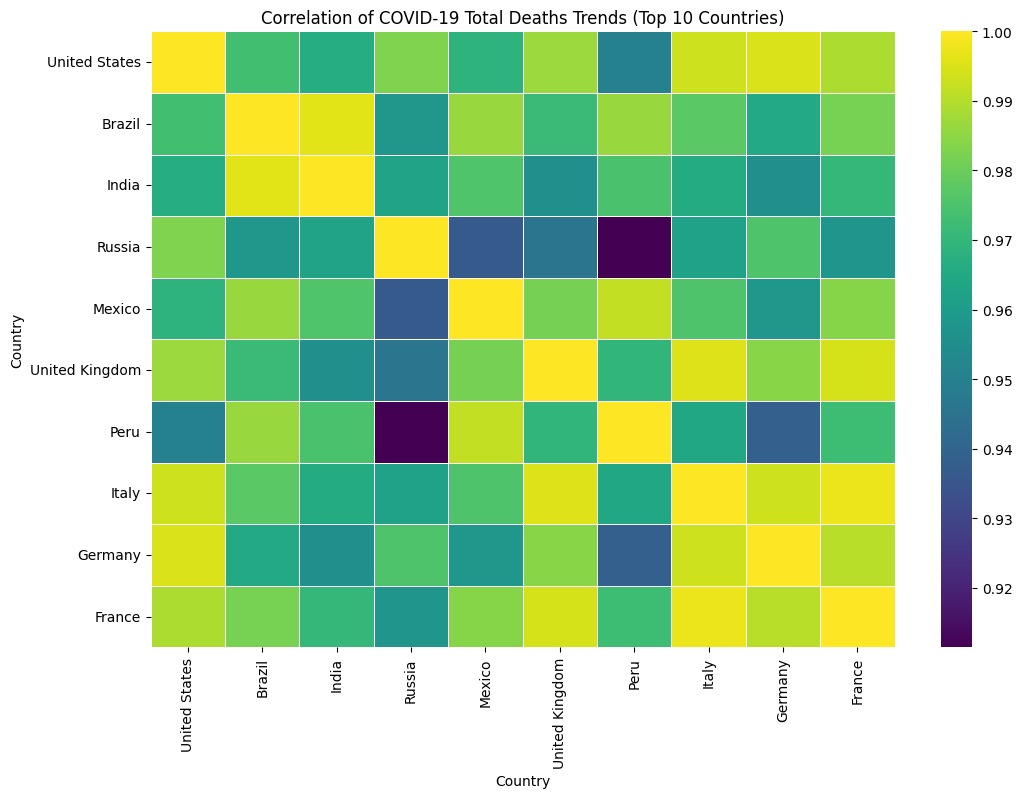

```python
## Call the visualization functions
print("Generating visualizations...")

print("\nVisualization 1. Calling to create correlation heatmap...")
# To Do: Call the create_corretlation_heatmap() function
try:
    create_correlation_heatmap(covid_clean_df)
except Exception as e:
    print(f"Error generating correlation heatmap: {e}")
```

```
Visualization 2. Calling to create bar chart...
Creating bar chart for top 20 countries...
```

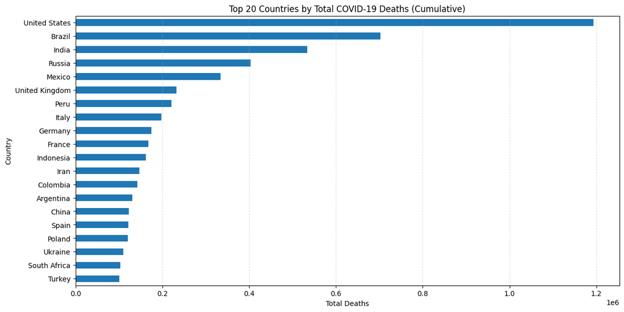

```python
print("Visualization 2. Calling to create bar chart...")
# To Do: Call the create_bar_chart() function
try:
    create_bar_chart(covid_clean_df)
except Exception as e:
    print(f"Error generating bar chart: {e}")
```

```
Visualization 3. Calling to create time series chart...
Creating global time series chart...
```

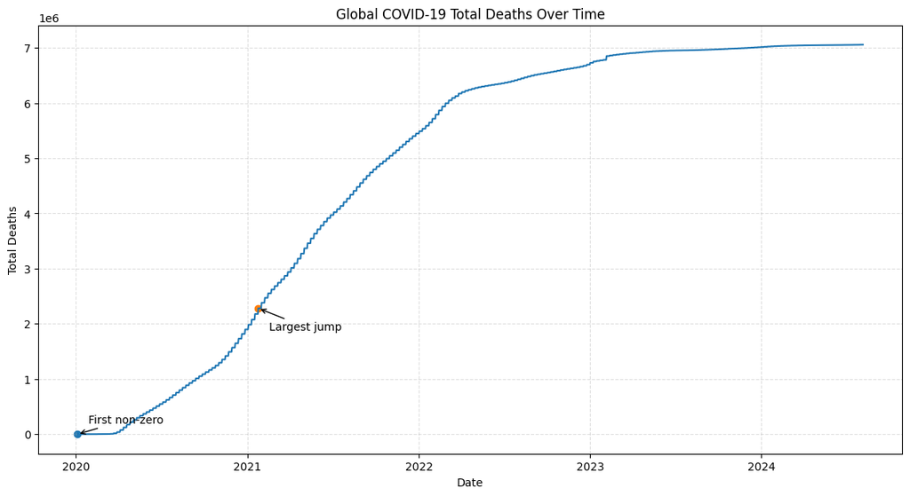

```
All visualizations have been generated, saved, and rendered.
```

```python
print("Visualization 3. Calling to create time series chart...")
# To Do: Call the create_time_series_chart() function
try:
    create_time_series_chart(covid_clean_df)
except Exception as e:
    print(f"Error generating time series chart: {e}")

print("\nAll visualizations have been generated, saved, and rendered.")
```

# Part Three: Interactive Visualizations

#### Use Plotly to create two interactive visualizations:

- One visualization should allow drill-down or zoom capabilities (e.g., zoom into specific time ranges or regions).
- Another should use Overview+Detail techniques (e.g., a main chart with a small overview window).

#### Add interactive elements, such as:

- Tooltips to display additional data on hover.
- Dropdown menus or buttons to filter data dynamically.

#### Expected Output

- **Drill-Down/Zoom Chart:** A line chart of global deaths with zooming and a range slider.
- **Overview+Detail Chart:** A combined chart with an overview (total deaths globally) and a detailed view (deaths for the top 5 countries).

*Note:* For the interactive visualizations, ensure that you use the **{variable}.show()** function to call the chart to render in the output so that it can be assessed in the html output.

## Load the preprocessed dataset from Part One above

```python
## Load the preprocessed dataset from Part One above
# To Do: Load the cleaned/preprocessed dataset you created in Part 1 of this assignment. This dataset should be in the 'data' folder.

try:
    covid_interactive_df = pd.read_csv("data/COVID_total_deaths_preprocessed.csv", low_memory=False)
    print("Preprocessed dataset loaded successfully.")

    covid_interactive_df["date"] = pd.to_datetime(covid_interactive_df["date"], errors="coerce")
    covid_interactive_df = covid_interactive_df.dropna(subset=["date"]).copy()
    covid_interactive_df = covid_interactive_df.sort_values("date").reset_index(drop=True)

except FileNotFoundError:
    print("Error: Preprocessed dataset not found. Make sure Part One saved: data/COVID_total_deaths_preprocessed.csv")
except Exception as e:
    print(f"An unexpected error occurred while loading the preprocessed dataset: {e}")
```

```
Preprocessed dataset loaded successfully.
```

## Preview the dataset

```python
## Preview the dataset
print("Dataset Preview:")
# To Do: Display the first few rows of the dataset for preview.
print("Dataset shape:", covid_interactive_df.shape)
display(covid_interactive_df.head())
```

```
Dataset Preview:
Dataset shape: (1674, 247)
```

|  | date | World | Afghanistan | Africa | Albania | Algeria | American Samoa | Andorra | Angola | Anguilla | ... | Uruguay | Uzbekistan | Vanuatu | Vatican | Venezuela | Vietnam | Wallis and Futuna | Yemen | Zambia | Zimbabwe |
| --- | --- | --- | --- | --- | --- | --- | --- | --- | --- | --- | --- | --- | --- | --- | --- | --- | --- | --- | --- | --- | --- |
| 0 | 2020-01-05 | 0.0 | 0.0 | 0.0 | 0.0 | 0.0 | 0.0 | 0.0 | 0.0 | 0.0 | ... | 0.0 | 0.0 | 0.0 | 0 | 0.0 | 0.0 | 0.0 | 0.0 | 0.0 | 0.0 |
| 1 | 2020-01-06 | 0.0 | 0.0 | 0.0 | 0.0 | 0.0 | 0.0 | 0.0 | 0.0 | 0.0 | ... | 0.0 | 0.0 | 0.0 | 0 | 0.0 | 0.0 | 0.0 | 0.0 | 0.0 | 0.0 |
| 2 | 2020-01-07 | 0.0 | 0.0 | 0.0 | 0.0 | 0.0 | 0.0 | 0.0 | 0.0 | 0.0 | ... | 0.0 | 0.0 | 0.0 | 0 | 0.0 | 0.0 | 0.0 | 0.0 | 0.0 | 0.0 |
| 3 | 2020-01-08 | 0.0 | 0.0 | 0.0 | 0.0 | 0.0 | 0.0 | 0.0 | 0.0 | 0.0 | ... | 0.0 | 0.0 | 0.0 | 0 | 0.0 | 0.0 | 0.0 | 0.0 | 0.0 | 0.0 |
| 4 | 2020-01-09 | 0.0 | 0.0 | 0.0 | 0.0 | 0.0 | 0.0 | 0.0 | 0.0 | 0.0 | ... | 0.0 | 0.0 | 0.0 | 0 | 0.0 | 0.0 | 0.0 | 0.0 | 0.0 | 0.0 |

5 rows × 247 columns

## Create Visualizations

### Visualization 1: Drill-Down/Zoom Capabilities

*Hints:* Use **show()** to render your interactive chart inside the notebook in an html exportable format.

```python
def create_drill_down_chart(data):
    print("\nCreating drill-down/zoom visualization...")
    # To Do: Summing the deaths globally by date

    df = data.copy()
    df["date"] = pd.to_datetime(df["date"], errors="coerce")
    df = df.dropna(subset=["date"]).sort_values("date")

    # If the dataset is normalized and heavily rounded, the last months can appear “flat”
    # Using the raw dataset for this chart makes zooming meaningful.
    raw_df = pd.read_csv("data/COVID_total_deaths.csv", low_memory=False)
    raw_df["date"] = pd.to_datetime(raw_df["date"], errors="coerce")
    raw_df = raw_df.dropna(subset=["date"]).sort_values("date")

    if "World" in raw_df.columns:
        global_by_date = raw_df["World"]
        y_label = "Total Deaths"
        title_suffix = "Raw totals (World column)"
    else:
        global_by_date = raw_df.drop(columns=["date"]).sum(axis=1, numeric_only=True)
        y_label = "Total Deaths (Summed)"
        title_suffix = "Raw totals (summed columns)"

    global_ts = pd.DataFrame({
        "date": raw_df["date"],
        "global_total_deaths": global_by_date
    })

    # To Do: Create an interactive time series chart with zoom capability
    fig = px.line(
        global_ts,
        x="date",
        y="global_total_deaths",
        title=f"Global COVID-19 Total Deaths Over Time (Interactive) — {title_suffix}",
        labels={"date": "Date", "global_total_deaths": y_label}
    )

    fig.update_layout(
        template="plotly_white",
        hovermode="x unified"
    )

    fig.update_xaxes(
        rangeslider_visible=True,
        rangeselector=dict(
            buttons=list([
                dict(count=1, label="1m", step="month", stepmode="backward"),
                dict(count=6, label="6m", step="month", stepmode="backward"),
                dict(count=1, label="1y", step="year", stepmode="backward"),
                dict(step="all", label="All")
            ])
        )
    )

    # To Do: Show the chart
    fig.show()
```

### Visualization 2: Overview+Detail Chart

*Hints:* Use **show()** to render your interactive chart inside the notebook in an html exportable format.

```python
def create_overview_detail_chart(data):
    print("\nCreating overview+detail visualization...")
    # To Do: Aggregating data for the top 5 countries by total deaths

    # Use raw data so the “top 5” and the detailed view remain meaningful
    raw_df = pd.read_csv("data/COVID_total_deaths.csv", low_memory=False)
    raw_df["date"] = pd.to_datetime(raw_df["date"], errors="coerce")
    raw_df = raw_df.dropna(subset=["date"]).sort_values("date")

    totals_raw = raw_df.drop(columns=["date"]).iloc[-1].sort_values(ascending=False)

    exclude = {
        "World", "Africa", "Europe", "North America", "South America", "Asia", "Oceania",
        "European Union (27)", "High-income countries", "Upper-middle-income countries",
        "Lower-middle-income countries", "Low-income countries"
    }
    totals_raw = totals_raw.drop(labels=[c for c in exclude if c in totals_raw.index], errors="ignore")

    top_5 = totals_raw.head(5).index.tolist()
    print("Top 5 countries selected:", top_5)

    # To Do: Filter the dataset for the top 5 countries
    detail_df = raw_df[["date"] + top_5].copy()

    # To Do: Create an overview+detail chart
    fig = make_subplots(
        rows=2, cols=1, shared_xaxes=True, vertical_spacing=0.12,
        row_heights=[0.30, 0.70],
        subplot_titles=("Overview: Global Trend (World)", "Detail: Top 5 Countries")
    )

    # To Do: Do the Overview portion of the chart (small chart)
    if "World" in raw_df.columns:
        overview_y = raw_df["World"]
        overview_name = "World"
    else:
        overview_y = raw_df.drop(columns=["date"]).sum(axis=1, numeric_only=True)
        overview_name = "Summed Total (Fallback)"

    fig.add_trace(
        go.Scatter(x=raw_df["date"], y=overview_y, mode="lines", name=overview_name),
        row=1, col=1
    )

    # To Do: Do the Detail portion of the chart (main chart)
    for country in top_5:
        fig.add_trace(
            go.Scatter(x=detail_df["date"], y=detail_df[country], mode="lines", name=country),
            row=2, col=1
        )

    # To Do: Configure layout
    buttons = []
    visible_all = [True] + [True] * len(top_5)
    buttons.append(dict(label="All Top 5", method="update", args=[{"visible": visible_all}]))

    for i, country in enumerate(top_5, start=1):
        visible_one = [True] + [False] * len(top_5)
        visible_one[i] = True
        buttons.append(dict(label=country, method="update", args=[{"visible": visible_one}]))

    fig.update_layout(
        template="plotly_white",
        title="COVID-19 Total Deaths: Overview + Detail (Interactive)",
        hovermode="x unified",
        updatemenus=[dict(buttons=buttons, direction="down", x=1.02, y=0.65, xanchor="left", yanchor="top")],
        margin=dict(r=180)
    )

    fig.update_xaxes(rangeslider_visible=True, row=2, col=1)
    fig.update_yaxes(title_text="Overview Value", row=1, col=1)
    fig.update_yaxes(title_text="Country Value", row=2, col=1)
    fig.update_xaxes(title_text="Date", row=2, col=1)

    # To Do: Show the chart
    fig.show()
```

## Call the visualization functions

*Reminder:* For the interactive visualizations, ensure that you use the **{variable}.show()** function to call the chart to render in the output so that it can be assessed in the html output.

```python
print("Generating visualizations...")

print("\nVisualization 1. Creating Drill-Down/Zoom Capabilities...")
# To Do: Call the create_drill_down_chart() function
try:
    create_drill_down_chart(covid_interactive_df)
except Exception as e:
    print(f"Error generating drill-down/zoom visualization: {e}")
```

```
Generating visualizations...

Visualization 1. Creating Drill-Down/Zoom Capabilities...

Creating drill-down/zoom visualization...
```

[interactive chart not shown]

```python
print("Visualization 2. Creating Overview+Detail Chart...")
# To Do: Call the create_overview_detail_chart() function
try:
    create_overview_detail_chart(covid_interactive_df)
except Exception as e:
    print(f"Error generating overview+detail visualization: {e}")

print("\nAll visualizations have been generated.")
```

```
Visualization 2. Creating Overview+Detail Chart...

Creating overview+detail visualization...
Top 5 countries selected: ['United States', 'Brazil', 'India', 'Russia', 'Mexico']
```

[interactive chart not shown]

```
All visualizations have been generated.
```

# Part Four: Customization and Animation

Using the original dataset `data/COVID_total_deaths.csv` (without normalization so as to ensure animation shows useful data points that are not scaled).

#### Customize the visualizations with matplotlib animation.

- A consistent theme or style (e.g., custom fonts, colors, gridlines).
- Layout optimization to ensure clarity and usability.

#### Add animation or transitions to one of the interactive visualizations

For example you can add animations to show changes over time (e.g., an animated line chart).

*Note:* For the interactive visualizations, ensure that you use the **{variable}.show()** function to call the chart to render in the output so that it can be assessed in the html output.

## Load the Dataset

```python
## Load the Dataset
# To Do: Load the original dataset `data/COVID_total_deaths.csv` from the 'data' folder.

try:
    covid_raw_anim_df = pd.read_csv("data/COVID_total_deaths.csv", low_memory=False)
    print("Raw dataset loaded successfully.")
    display(covid_raw_anim_df.head())

except FileNotFoundError:
    print("Error: data/COVID_total_deaths.csv not found. Check that the file exists in the data folder.")

except Exception as e:
    print(f"An unexpected error occurred while loading the raw dataset: {e}")
```

```
Raw dataset loaded successfully.
```

|  | date | World | Afghanistan | Africa | Albania | Algeria | American Samoa | Andorra | Angola | Anguilla | ... | Uruguay | Uzbekistan | Vanuatu | Vatican | Venezuela | Vietnam | Wallis and Futuna | Yemen | Zambia | Zimbabwe |
| --- | --- | --- | --- | --- | --- | --- | --- | --- | --- | --- | --- | --- | --- | --- | --- | --- | --- | --- | --- | --- | --- |
| 0 | 2020-01-05 | 3 | 0 | 0 | 0 | 0 | 0 | 0 | 0 | 0 | ... | 0 | 0 | 0 | 0 | 0 | 0 | 0 | 0 | 0 | 0 |
| 1 | 2020-01-06 | 3 | 0 | 0 | 0 | 0 | 0 | 0 | 0 | 0 | ... | 0 | 0 | 0 | 0 | 0 | 0 | 0 | 0 | 0 | 0 |
| 2 | 2020-01-07 | 3 | 0 | 0 | 0 | 0 | 0 | 0 | 0 | 0 | ... | 0 | 0 | 0 | 0 | 0 | 0 | 0 | 0 | 0 | 0 |
| 3 | 2020-01-08 | 3 | 0 | 0 | 0 | 0 | 0 | 0 | 0 | 0 | ... | 0 | 0 | 0 | 0 | 0 | 0 | 0 | 0 | 0 | 0 |
| 4 | 2020-01-09 | 3 | 0 | 0 | 0 | 0 | 0 | 0 | 0 | 0 | ... | 0 | 0 | 0 | 0 | 0 | 0 | 0 | 0 | 0 | 0 |

5 rows × 247 columns

## Clean and Preprocess the Data

```python
## Clean and Preprocess the Data
def clean_data(data):
    print("\nCleaning the dataset...")

    # To Do: Remove countries with all zero deaths
    df = data.copy()

    if "date" not in df.columns:
        raise ValueError("Expected a 'date' column, but none was found in the dataset.")

    non_date_cols = [c for c in df.columns if c != "date"]

    # Keep only columns that have at least one non-zero value
    keep_cols = ["date"] + [c for c in non_date_cols if df[c].sum(numeric_only=True) > 0]
    df = df[keep_cols].copy()

    # To Do: Remove rows (dates) with all zero deaths
    df = df.loc[df.drop(columns=["date"]).sum(axis=1, numeric_only=True) > 0].copy()

    # To Do: Convert 'date' column to datetime, display filtered dataset shape & return filtered data
    df["date"] = pd.to_datetime(df["date"], errors="coerce")
    df = df.dropna(subset=["date"]).copy()
    df = df.sort_values("date").reset_index(drop=True)

    print("Filtered dataset shape:", df.shape)
    return df
```

```python
# To Do: Call the clean_data() function.
covid_raw_clean = clean_data(covid_raw_anim_df)
display(covid_raw_clean.head())
```

```
Cleaning the dataset...
Filtered dataset shape: (1674, 239)
```

|  | date | World | Afghanistan | Africa | Albania | Algeria | American Samoa | Andorra | Angola | Anguilla | ... | Upper-middle-income countries | Uruguay | Uzbekistan | Vanuatu | Venezuela | Vietnam | Wallis and Futuna | Yemen | Zambia | Zimbabwe |
| --- | --- | --- | --- | --- | --- | --- | --- | --- | --- | --- | --- | --- | --- | --- | --- | --- | --- | --- | --- | --- | --- |
| 0 | 2020-01-05 | 3 | 0 | 0 | 0 | 0 | 0 | 0 | 0 | 0 | ... | 0 | 0 | 0 | 0 | 0 | 0 | 0 | 0 | 0 | 0 |
| 1 | 2020-01-06 | 3 | 0 | 0 | 0 | 0 | 0 | 0 | 0 | 0 | ... | 0 | 0 | 0 | 0 | 0 | 0 | 0 | 0 | 0 | 0 |
| 2 | 2020-01-07 | 3 | 0 | 0 | 0 | 0 | 0 | 0 | 0 | 0 | ... | 0 | 0 | 0 | 0 | 0 | 0 | 0 | 0 | 0 | 0 |
| 3 | 2020-01-08 | 3 | 0 | 0 | 0 | 0 | 0 | 0 | 0 | 0 | ... | 0 | 0 | 0 | 0 | 0 | 0 | 0 | 0 | 0 | 0 |
| 4 | 2020-01-09 | 3 | 0 | 0 | 0 | 0 | 0 | 0 | 0 | 0 | ... | 0 | 0 | 0 | 0 | 0 | 0 | 0 | 0 | 0 | 0 |

5 rows × 239 columns

## Select Top 10 Countries

```python
## Select Top 10 Countries
def select_top_countries(data):
    print("\nSelecting top 10 countries by total deaths...")

    # To Do: Calculate total deaths by country.
    totals = data.drop(columns=["date"]).iloc[-1].sort_values(ascending=False)

    # To Do: Exclude these aggregate regions or groups
    #    "World",
    #    "Africa",
    #    "Europe",
    #    "North America",
    #    "South America",
    #    "Asia",
    #    "European Union (27)",
    #    "High-income countries",
    #    "Upper-middle-income countries",
    #    "Lower-middle-income countries"
    exclude = [
        "World", "Africa", "Europe", "North America", "South America", "Asia", "Oceania",
        "European Union (27)",
        "High-income countries", "Upper-middle-income countries",
        "Lower-middle-income countries", "Low-income countries"
    ]
    totals = totals.drop(labels=[x for x in exclude if x in totals.index], errors="ignore")

    # To Do: Select top 10 individual countries
    top10 = totals.head(10).index.tolist()

    print("\nTop 10 individual countries by total deaths:")
    # To Do: Display the top 10 individual countries
    print(top10)

    # To Do: Filter the dataset for the top 10 countries
    filtered = data[["date"] + top10].copy()

    # To Do: Aggregate data weekly (downsample)
    # Monthly downsample keeps the animation smaller (helps with HTML embed size limits)
    monthly = (
        filtered.set_index("date")
                .resample("MS")
                .max()
                .reset_index()
    )

    # To Do: Display the print(f"\nFiltered dataset shape after selecting. Return filtered data.
    print(f"\nFiltered dataset shape after selecting top 10 & monthly downsample: {monthly.shape}")

    return monthly
```

```python
# To Do: Call select_top_countries()
covid_top10_monthly = select_top_countries(covid_raw_clean)
display(covid_top10_monthly.head())
```

```
Selecting top 10 countries by total deaths...

Top 10 individual countries by total deaths:
['United States', 'Brazil', 'India', 'Russia', 'Mexico', 'United Kingdom', 'Peru', 'Italy', 'Germany', 'France']

Filtered dataset shape after selecting top 10 & monthly downsample: (56, 11)
```

|  | date | United States | Brazil | India | Russia | Mexico | United Kingdom | Peru | Italy | Germany | France |
| --- | --- | --- | --- | --- | --- | --- | --- | --- | --- | --- | --- |
| 0 | 2020-01-01 | 0 | 0 | 0 | 0 | 0 | 0 | 0 | 0 | 6 | 0 |
| 1 | 2020-02-01 | 0 | 0 | 0 | 0 | 0 | 2 | 0 | 2 | 10 | 0 |
| 2 | 2020-03-01 | 2106 | 92 | 25 | 8 | 28 | 2489 | 71 | 10023 | 2045 | 2712 |
| 3 | 2020-04-01 | 53434 | 3670 | 824 | 747 | 2758 | 33860 | 2910 | 26384 | 8149 | 14158 |
| 4 | 2020-05-01 | 105325 | 27878 | 5164 | 4693 | 19598 | 52003 | 19483 | 33340 | 9136 | 18463 |

## Prepare Data for Animation

```python
## Prepare Data for Animation
print("Preparing data for animation...")

# To Do: Melt the data for easier plotting
melted = covid_top10_monthly.melt(
    id_vars="date",
    var_name="location",
    value_name="total_deaths"
)

melted = melted.sort_values(["location", "date"]).reset_index(drop=True)
```

```
Preparing data for animation...
```

```python
print("Data prepared successfully!")
# To Do: Display melted data
display(melted.head(10))
```

```
Data prepared successfully!
```

|  | date | location | total_deaths |
| --- | --- | --- | --- |
| 0 | 2020-01-01 | Brazil | 0 |
| 1 | 2020-02-01 | Brazil | 0 |
| 2 | 2020-03-01 | Brazil | 92 |
| 3 | 2020-04-01 | Brazil | 3670 |
| 4 | 2020-05-01 | Brazil | 27878 |
| 5 | 2020-06-01 | Brazil | 55961 |
| 6 | 2020-07-01 | Brazil | 85238 |
| 7 | 2020-08-01 | Brazil | 119504 |
| 8 | 2020-09-01 | Brazil | 140537 |
| 9 | 2020-10-01 | Brazil | 156471 |

## Create the Matplotlib Animation

```
Creating the animation...ignore static output
```

[figure not shown]

```python
## Create the Matplotlib Animation
print("Creating the animation...ignore static output")

# To Do: Initialize the plot
fig, ax = plt.subplots(figsize=(12, 6))

# To Do: Set the axis limits and labels
countries = melted["location"].unique().tolist()

max_y = melted["total_deaths"].max()
max_y = max(max_y, 1)

ax.set_xlim(melted["date"].min(), melted["date"].max())
ax.set_ylim(0, max_y * 1.05)

ax.set_title("Animated COVID-19 Total Deaths (Top 10 Countries)")
ax.set_xlabel("Date")
ax.set_ylabel("Total Deaths")
ax.grid(True, linestyle="--", alpha=0.4)

# Pre-build time series per country for faster updates
series_by_country = {
    c: melted[melted["location"] == c][["date", "total_deaths"]].reset_index(drop=True)
    for c in countries
}

# Create line objects once so init/update can reference them safely
lines = {}
for c in countries:
    line_obj, = ax.plot([], [], label=c)
    lines[c] = line_obj

ax.legend(loc="upper left", bbox_to_anchor=(1.02, 1), fontsize="small", borderaxespad=0)
```

### Function to initialize the animation

```python
### Function to initialize the animation
def init():
    # To Do: Create a for loop here to initialize lines values. Return lines values.

    # Start each line with no data so the animation builds from blank
    for line in lines.values():
        line.set_data([], [])

    # Return the line artists so FuncAnimation knows what to draw
    return list(lines.values())
```

### Function to update the animation frame-by-frame

```python
### Function to update the animation frame-by-frame
def update(frame):
    # To Do: Update the animation frame-by-frame.

    # Each frame reveals data up to the current index (0..frame)
    for c in countries:
        df_c = series_by_country[c]

        x = df_c["date"].iloc[:frame + 1]
        y = df_c["total_deaths"].iloc[:frame + 1]

        lines[c].set_data(x, y)

    # Return updated artists so FuncAnimation redraws them properly
    return list(lines.values())
```

### Create the animation

*Hints:* Use **FuncAnimation()** to initate the animation visualization. Use **HTML({variable}.to_jshtml())** to render your animation inside the notebook in an html exportable format.

```python
### Create the animation
# To Do: Call FuncAnimation() to create the animation -
#        interval=200 means each frame witll last 200 ms (0.2 sec). Small values make the animation faster

# Downsampling to monthly keeps the embedded animation smaller and helps avoid HTML size limits
frames = len(covid_top10_monthly)

anim = FuncAnimation(
    fig,                 # matplotlib figure object
    update,              # function that updates lines each frame
    frames=frames,       # total number of frames
    init_func=init,      # initialize lines to blank
    interval=250         # slightly slower = fewer embedded frames per second in HTML playback
)

# To Do: Show the animation
display(HTML(anim.to_jshtml()))

# Close the static figure so only the animation shows in the notebook/HTML export
plt.close(fig)
```

[figure not shown]